# MSB7102Assignment

Doreen Ato Adera

2023-11-17

## Section A: Data exploration

### Read the metaFile.csv file into your R sessions and perform the following operations

```r
getwd()
```

```
## [1] "/home/doreen/ATO/PhD Bioinformatics/MSB7102 Bioconductor and R/R_assignment"
```

```r
metaFile1.csv <- read.csv("metaFile.csv")
metaFile1.csv
```

```
##    sample_id Participant Treatment
## 1   sample_1           C         4
## 2   sample_2           B         3
## 3   sample_3           B         2
## 4   sample_4           C         1
## 5   sample_5           C         3
## 6   sample_6           A         4
## 7   sample_7           B         0
## 8   sample_8           A         1
## 9   sample_9           B         4
## 10 sample_10           C         0
## 11 sample_11           A         2
## 12 sample_12           A         3
## 13 sample_13           B         1
## 14 sample_14           C         2
```

[output cut: 36 more lines]

#### i) Return the number of variables/columns and records/rows

```r
#Returning number of variables/columns
paste('Number of columns: ', ncol(metaFile1.csv))
```

```
## [1] "Number of columns:  3"
```

```r
#Returning number of records/rows
paste ('Number of rows: ' , nrow(metaFile1.csv))
```

```
## [1] "Number of rows:  50"
```

#### ii) Count the number of samples which were obtained for each level of treatment

```r
 number_of_sample_per_treatment_level <- table(metaFile1.csv$Treatment)
 number_of_sample_per_treatment_level
```

```
##
##  0  1  2  3  4
##  9 10 10 11 10
```

#### iii) Count the number of samples which were obtained for each participant

```r
number_of_sample_per_participant <- table(metaFile1.csv$Participant)
number_of_sample_per_participant
```

```
##
##  A  B  C
## 15 17 18
```

#### iv)Extract records for samples obtained at treatment levels 0,2 and 4

```r
library(dplyr)
metaFile1.csv %>% filter(Treatment %in% c(0, 2, 4))
```

```
##    sample_id Participant Treatment
## 1   sample_1           C         4
## 2   sample_3           B         2
## 3   sample_6           A         4
## 4   sample_7           B         0
## 5   sample_9           B         4
## 6  sample_10           C         0
## 7  sample_11           A         2
## 8  sample_14           C         2
## 9  sample_15           A         0
## 10 sample_16           C         4
## 11 sample_18           B         2
## 12 sample_21           A         4
## 13 sample_22           B         0
## 14 sample_24           B         4
## 15 sample_25           C         0
## 16 sample_26           A         2
## 17 sample_29           C         2
## 18 sample_30           A         0
## 19 sample_31           C         4
## 20 sample_33           B         2
## 21 sample_36           A         4
## 22 sample_37           B         0
## 23 sample_39           B         4
## 24 sample_40           C         0
## 25 sample_41           A         2
## 26 sample_44           C         2
## 27 sample_45           A         0
## 28 sample_46           C         4
## 29 sample_48           B         2
```

#### v)Extract records for samples obtained from participants A and C

```r
library(dplyr)
metaFile1.csv %>% filter(Participant %in% c("A" , "C"))
```

```
##    sample_id Participant Treatment
## 1   sample_1           C         4
## 2   sample_4           C         1
## 3   sample_5           C         3
## 4   sample_6           A         4
## 5   sample_8           A         1
## 6  sample_10           C         0
## 7  sample_11           A         2
## 8  sample_12           A         3
## 9  sample_14           C         2
## 10 sample_15           A         0
## 11 sample_16           C         4
## 12 sample_19           C         1
## 13 sample_20           C         3
## 14 sample_21           A         4
```

[output cut: 19 more lines]

#### vi) Count the number of samples under each participant groups per treatment level.

```r
table(metaFile1.csv$Participant, metaFile1.csv$Treatment)
```

```
##
##     0 1 2 3 4
##   A 3 3 3 3 3
##   B 3 3 4 4 3
##   C 3 4 3 4 4
```

## Section B: Data Exploration 2

### Import AssignmentFile.csv file and use it to perform the following operations.

```r
getwd()
```

```
## [1] "/home/doreen/ATO/PhD Bioinformatics/MSB7102 Bioconductor and R/R_assignment"
```

```r
AssignmentFile1.csv <- read.csv("AssignmentFile.csv")

AssignmentFile1.csv
```

```
##      samples      Conc1     Conc2      Conc3
## 1   sample_1 5.93804869 2.2877765  3.2487625
## 2   sample_2 3.39846291 4.0508845  3.2359883
## 3   sample_3 1.94647521 1.2918230  1.2597982
## 4   sample_4 1.75043775 4.5088147  2.6153558
## 5   sample_5 2.90319389 2.6006057  1.6662130
## 6   sample_6 0.74662991 3.5212946  1.3361532
## 7   sample_7 2.61412606 1.7075223  2.9077324
## 8   sample_8 2.86823250 0.6855859  0.7057831
## 9   sample_9 4.25332693 1.5380970  4.1286548
## 10 sample_10 2.53152856 1.4914619  2.8437762
## 11 sample_11 2.02469134 1.0988479  3.0460737
## 12 sample_12 1.68888486 1.5382037  1.5721820
## 13 sample_13 0.07948294 1.8417749  5.4324201
## 14 sample_14 2.35002162 2.8437762  3.5107200
```

[output cut: 36 more lines]

#### i) Return the number of variables/columns and records/rows

```r
# Return the number of variables/ columns
paste ('Number of columns: ' , ncol(AssignmentFile1.csv))
```

```
## [1] "Number of columns:  4"
```

```r
# Return the number of variables/ columns
paste ('Number of rows: ' , nrow(AssignmentFile1.csv))
```

```
## [1] "Number of rows:  50"
```

#### ii) Compute the average concentration for each of the concentrations (ie Conc1, Conc2 and Conc3)

```r
mean(AssignmentFile1.csv$Conc1)
```

```
## [1] 2.23591
```

```r
mean(AssignmentFile1.csv$Conc2)
```

```
## [1] 2.631801
```

```r
mean(AssignmentFile1.csv$Conc3)
```

```
## [1] 2.57969
```

```r
#or
colMeans(AssignmentFile1.csv[sapply(AssignmentFile1.csv, is.numeric)])
```

```
##    Conc1    Conc2    Conc3
## 2.235910 2.631801 2.579690
```

#### iii) Compute the average Conc for each sample (Hint: Obtain this by taking the mean of Conc1,Conc2 and Conc3).

```r
concmeans <- rowMeans(AssignmentFile1.csv [1:50, 2:4])
concmeans
```

```
##        1        2        3        4        5        6        7        8
## 3.824863 3.561779 1.499365 2.958203 2.390004 1.868026 2.409794 1.419867
##        9       10       11       12       13       14       15       16
## 3.306693 2.288922 2.056538 1.599757 2.451226 2.901506 3.258827 1.753767
##       17       18       19       20       21       22       23       24
## 2.443834 2.657674 1.782624 2.034364 1.998999 2.163061 2.544692 2.452164
##       25       26       27       28       29       30       31       32
## 2.092057 3.003388 3.313401 1.765348 1.624170 3.037058 2.448267 2.038269
##       33       34       35       36       37       38       39       40
## 2.833067 1.957261 1.668823 2.192923 2.616311 3.646680 2.841996 2.949213
##       41       42       43       44       45       46       47       48
## 3.229693 2.329251 3.211285 2.842079 2.998275 2.744949 1.683616 2.672564
##       49       50
## 2.434259 2.322598
```

#### iv) Extend this data-frame by introducing a new variable say ”Concmean” to contain the average Concentartion of values computed above

```r
AssignmentFile2.csv <- mutate(AssignmentFile1.csv, concmeans)
AssignmentFile2.csv
```

```
##      samples      Conc1     Conc2      Conc3 concmeans
## 1   sample_1 5.93804869 2.2877765  3.2487625  3.824863
## 2   sample_2 3.39846291 4.0508845  3.2359883  3.561779
## 3   sample_3 1.94647521 1.2918230  1.2597982  1.499365
## 4   sample_4 1.75043775 4.5088147  2.6153558  2.958203
## 5   sample_5 2.90319389 2.6006057  1.6662130  2.390004
## 6   sample_6 0.74662991 3.5212946  1.3361532  1.868026
## 7   sample_7 2.61412606 1.7075223  2.9077324  2.409794
## 8   sample_8 2.86823250 0.6855859  0.7057831  1.419867
## 9   sample_9 4.25332693 1.5380970  4.1286548  3.306693
## 10 sample_10 2.53152856 1.4914619  2.8437762  2.288922
## 11 sample_11 2.02469134 1.0988479  3.0460737  2.056538
## 12 sample_12 1.68888486 1.5382037  1.5721820  1.599757
## 13 sample_13 0.07948294 1.8417749  5.4324201  2.451226
## 14 sample_14 2.35002162 2.8437762  3.5107200  2.901506
```

[output cut: 36 more lines]

#### v)Obtain the basic statics (min, max, mean, median, quartiles, variance, standard deviation)for all the variables including Concmean

```r
summary(AssignmentFile2.csv)
```

```
##    samples              Conc1             Conc2            Conc3
##  Length:50          Min.   :0.07948   Min.   :0.6856   Min.   :-0.2755
##  Class :character   1st Qu.:1.64835   1st Qu.:1.8380   1st Qu.: 1.8432
##  Mode  :character   Median :2.22227   Median :2.5963   Median : 2.6424
##                     Mean   :2.23591   Mean   :2.6318   Mean   : 2.5797
##                     3rd Qu.:2.72488   3rd Qu.:3.2873   3rd Qu.: 3.1898
##                     Max.   :5.93805   Max.   :4.7706   Max.   : 5.4324
##    concmeans
##  Min.   :1.420
##  1st Qu.:2.035
##  Median :2.446
##  Mean   :2.482
##  3rd Qu.:2.937
##  Max.   :3.825
```

```r
apply(AssignmentFile2.csv[, 2:5], 2, sd)
```

```
##     Conc1     Conc2     Conc3 concmeans
## 1.0384617 0.9653108 1.1169179 0.6018165
```

```r
apply(AssignmentFile2.csv[, 2:5], 2, var)
```

```
##     Conc1     Conc2     Conc3 concmeans
## 1.0784026 0.9318250 1.2475056 0.3621831
```

## Section C: Data Manipulation and Graphics

#### i)Remove variables Conc1, Conc2 and Conc3 from the concentration data-frame (At this point, this data-frame should only have information about sample ids and average Conc.)

```r
AssignmentFile2.csv [ 2:4] = NULL
head(AssignmentFile2.csv)
```

```
##    samples concmeans
## 1 sample_1  3.824863
## 2 sample_2  3.561779
## 3 sample_3  1.499365
## 4 sample_4  2.958203
## 5 sample_5  2.390004
## 6 sample_6  1.868026
```

#### ii)Combine (merge) information in the two data-frames concentration with metadata.

```r
library(dplyr)
merged_datasets <- merge(metaFile1.csv, AssignmentFile2.csv, by.x = "sample_id", by.y = "samples", all = TRUE)
merged_datasets
```

```
##    sample_id Participant Treatment concmeans
## 1   sample_1           C         4  3.824863
## 2  sample_10           C         0  2.288922
## 3  sample_11           A         2  2.056538
## 4  sample_12           A         3  1.599757
## 5  sample_13           B         1  2.451226
## 6  sample_14           C         2  2.901506
## 7  sample_15           A         0  3.258827
## 8  sample_16           C         4  1.753767
## 9  sample_17           B         3  2.443834
## 10 sample_18           B         2  2.657674
## 11 sample_19           C         1  1.782624
## 12  sample_2           B         3  3.561779
## 13 sample_20           C         3  2.034364
## 14 sample_21           A         4  1.998999
```

[output cut: 36 more lines]

#### iii) Check the size of the combined data-frame and verify it is what is expected (Hint: You maywant to use the dim() and colnames() and head() functions).

```r
dim(merged_datasets)
```

```
## [1] 50  4
```

```r
colnames(merged_datasets)
```

```
## [1] "sample_id"   "Participant" "Treatment"   "concmeans"
```

```r
head(merged_datasets)
```

```
##   sample_id Participant Treatment concmeans
## 1  sample_1           C         4  3.824863
## 2 sample_10           C         0  2.288922
## 3 sample_11           A         2  2.056538
## 4 sample_12           A         3  1.599757
## 5 sample_13           B         1  2.451226
## 6 sample_14           C         2  2.901506
```

#### iv)From the combined dataset, extract records for samples for participants B and C obtainedat treatment levels 2,3 and 4. Assign this to variable “participantsBC”.

```r
library(dplyr)
participantsBC <- merged_datasets%>% filter(Participant%in%c("B","C") & Treatment%in%c(2,3,4))
participantsBC
```

```
##    sample_id Participant Treatment concmeans
## 1   sample_1           C         4  3.824863
## 2  sample_14           C         2  2.901506
## 3  sample_16           C         4  1.753767
## 4  sample_17           B         3  2.443834
## 5  sample_18           B         2  2.657674
## 6   sample_2           B         3  3.561779
## 7  sample_20           C         3  2.034364
## 8  sample_24           B         4  2.452164
## 9  sample_29           C         2  1.624170
## 10  sample_3           B         2  1.499365
## 11 sample_31           C         4  2.448267
## 12 sample_32           B         3  2.038269
## 13 sample_33           B         2  2.833067
## 14 sample_35           C         3  1.668823
## 15 sample_39           B         4  2.841996
## 16 sample_44           C         2  2.842079
## 17 sample_46           C         4  2.744949
## 18 sample_47           B         3  1.683616
## 19 sample_48           B         2  2.672564
## 20  sample_5           C         3  2.390004
## 21 sample_50           C         3  2.322598
## 22  sample_9           B         4  3.306693
```

#### v)Using ”participantsBC” or otherwise, compute the average Concentration for participantsB and C under treatments 2, 3 and 4. (Hint: Aggregate or group_by function). In this case,we expect to get a single Concentration value for each participant for each treatment.

```r
library(dplyr)
participantsBCaverage <- participantsBC %>%
  group_by(Participant, Treatment) %>%
  summarise(average_concentration = mean(concmeans),.groups = "drop" )
participantsBCaverage
```

```
## # A tibble: 6 × 3
##   Participant Treatment average_concentration
##   <chr>           <int>                 <dbl>
## 1 B                   2                  2.42
## 2 B                   3                  2.43
## 3 B                   4                  2.87
## 4 C                   2                  2.46
## 5 C                   3                  2.10
## 6 C                   4                  2.69
```

#### vi) Use a for loop to change treatment levels from 0,1,2,3,4 to “very-low”, “low”, “moderate”,“high”, “very-high” respectively on the combined dataset.

```r
#merged_datasets_loop
merged_datasets_loop <- merged_datasets
merged_datasets_loop
```

```
##    sample_id Participant Treatment concmeans
## 1   sample_1           C         4  3.824863
## 2  sample_10           C         0  2.288922
## 3  sample_11           A         2  2.056538
## 4  sample_12           A         3  1.599757
## 5  sample_13           B         1  2.451226
## 6  sample_14           C         2  2.901506
## 7  sample_15           A         0  3.258827
## 8  sample_16           C         4  1.753767
## 9  sample_17           B         3  2.443834
## 10 sample_18           B         2  2.657674
## 11 sample_19           C         1  1.782624
## 12  sample_2           B         3  3.561779
## 13 sample_20           C         3  2.034364
## 14 sample_21           A         4  1.998999
```

[output cut: 36 more lines]

```r
for (n in 1:nrow(merged_datasets_loop)){
  if (merged_datasets_loop[n,3]==0){
    merged_datasets_loop[n,3]= "Very low"
  } else if (merged_datasets_loop[n,3]==1){
   merged_datasets_loop[n,3]="Low"
  } else if (merged_datasets_loop[n,3]==2){
    merged_datasets_loop[n,3]="Moderate"
  } else if (merged_datasets_loop[n,3]==3){
    merged_datasets_loop[n,3]="High"
  }else if (merged_datasets_loop[n,3]==4){
   merged_datasets_loop[n,3]="Very-High"
  }
}
merged_datasets_loop
```

```
##    sample_id Participant Treatment concmeans
## 1   sample_1           C Very-High  3.824863
## 2  sample_10           C  Very low  2.288922
## 3  sample_11           A  Moderate  2.056538
## 4  sample_12           A      High  1.599757
## 5  sample_13           B       Low  2.451226
## 6  sample_14           C  Moderate  2.901506
## 7  sample_15           A  Very low  3.258827
## 8  sample_16           C Very-High  1.753767
## 9  sample_17           B      High  2.443834
## 10 sample_18           B  Moderate  2.657674
## 11 sample_19           C       Low  1.782624
## 12  sample_2           B      High  3.561779
## 13 sample_20           C      High  2.034364
## 14 sample_21           A Very-High  1.998999
```

[output cut: 36 more lines]

#### vii) Write a function to change treatment levels from 0,1,2,3,4 to ”very-low”, ”low”,”moderate”, ”high”, ”very-high” respectively, use this with sapply() or other appropriatefunction to change treatment variable in combined dataset

```r
merged_datasets_func <- merged_datasets
merged_datasets_func
```

```
##    sample_id Participant Treatment concmeans
## 1   sample_1           C         4  3.824863
## 2  sample_10           C         0  2.288922
## 3  sample_11           A         2  2.056538
## 4  sample_12           A         3  1.599757
## 5  sample_13           B         1  2.451226
## 6  sample_14           C         2  2.901506
## 7  sample_15           A         0  3.258827
## 8  sample_16           C         4  1.753767
## 9  sample_17           B         3  2.443834
## 10 sample_18           B         2  2.657674
## 11 sample_19           C         1  1.782624
## 12  sample_2           B         3  3.561779
## 13 sample_20           C         3  2.034364
## 14 sample_21           A         4  1.998999
```

[output cut: 36 more lines]

```r
new_function  <- function(n) {
  label <- ifelse(n==0, "very low",
                  ifelse(n==1, "low",
                         ifelse(n==2, "moderate",
                                ifelse(n==3, "high",
                                       ifelse(n==4, "very high", NA)))))
  return(label)
}

merged_datasets_func$Treatment <- sapply(merged_datasets_func$Treatment, new_function)

merged_datasets_func
```

```
##    sample_id Participant Treatment concmeans
## 1   sample_1           C very high  3.824863
## 2  sample_10           C  very low  2.288922
## 3  sample_11           A  moderate  2.056538
## 4  sample_12           A      high  1.599757
## 5  sample_13           B       low  2.451226
## 6  sample_14           C  moderate  2.901506
## 7  sample_15           A  very low  3.258827
## 8  sample_16           C very high  1.753767
## 9  sample_17           B      high  2.443834
## 10 sample_18           B  moderate  2.657674
## 11 sample_19           C       low  1.782624
## 12  sample_2           B      high  3.561779
## 13 sample_20           C      high  2.034364
## 14 sample_21           A very high  1.998999
```

[output cut: 36 more lines]

#### viii)Check and comment on the time taken to perform the above two operations using the forloop and sapply(). (Hint: Use system.time() function).

```r
#time check for for_loop
system.time(
for (n in 1:nrow(merged_datasets_loop)){
  if (merged_datasets_loop[n,3]==0){
    merged_datasets_loop[n,3]= "Very low"
  } else if (merged_datasets_loop[n,3]==1){
   merged_datasets_loop[n,3]="Low"
  } else if (merged_datasets_loop[n,3]==2){
    merged_datasets_loop[n,3]="Moderate"
  } else if (merged_datasets_loop[n,3]==3){
    merged_datasets_loop[n,3]="High"
  }else if (merged_datasets_loop[n,3]==4){
   merged_datasets_loop[n,3]="Very High"
  }
} )
```

```
##    user  system elapsed
##   0.016   0.000   0.016
```

```r
#time check for sapply
system.time(
 merged_datasets_func$Treatment <- sapply(merged_datasets_func$Treatment, new_function)
)
```

```
##    user  system elapsed
##   0.001   0.001   0.002
```

#### vix)Using ggplot2 package, produce appropriate graphical representation of the combineddataset with the changed treatment levels. You may produce more than one form of plot.Export the image(s) as PNG, the plots should at-least have the following; – Legend – Title– Axis labels – White background

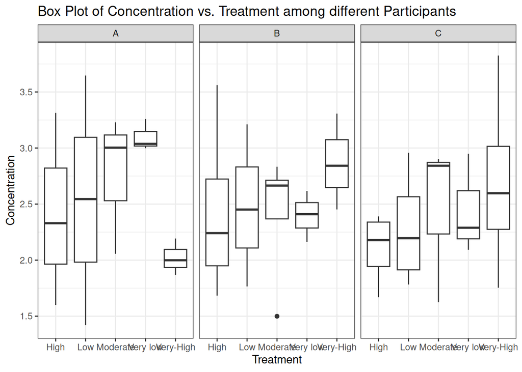

```r
library(ggplot2)
ggplot(data = merged_datasets_loop, mapping = aes(Treatment, y = concmeans)) + geom_boxplot() + theme_bw() + facet_wrap(~Participant) + labs(title = "Box Plot of Concentration vs. Treatment among different Participants",
       x = "Treatment",
       y = "Concentration")
```

## Section D:Classical hypothesis testing and statistical models in R

### For this section, use the file named statsFile.csv that contains information about participants involved in a study to explore the key predictors of a disease status with only a few variablesincluded for purposes of this exercise. Disease status is encoded into 0 and 1, where 0 means nodisease and 1 implies presence of disease. For each participant, six records were taken.

#### 1) How does BMI relate to BP for the all study participants? (Hint: Correlation,comparison of means and variances for BMI and BP)

```r
#reading data
getwd()
```

```
## [1] "/home/doreen/ATO/PhD Bioinformatics/MSB7102 Bioconductor and R/R_assignment"
```

```r
statsFile1 <- read.csv("statsFile.csv")
statsFile1
```

```
##          X      BMI       BP Gender Status Location
## 1     P_ 1 3.306331 1.848332   Male      1        C
## 2     P_ 2 3.144198 1.803189 Female      0        C
## 3     P_ 3 3.268586 1.837923 Female      1        B
## 4     P_ 4 3.175555 1.812009   Male      1        C
## 5     P_ 5 3.084312 1.786221 Female      1        A
## 6     P_ 6 3.227014 1.826389 Female      1        C
## 7     P_ 7 2.810668 1.706505   Male      1        A
## 8     P_ 8 3.080841 1.785232   Male      1        B
## 9     P_ 9 3.127907 1.798589   Male      1        C
## 10   P_ 10 2.986719 1.758213 Female      1        B
## 11   P_ 11 2.877521 1.726326 Female      0        B
## 12   P_ 12 3.059652 1.779186 Female      1        B
## 13   P_ 13 2.984433 1.757551 Female      0        B
## 14   P_ 14 3.425850 1.880905   Male      1        B
```

[output cut: 306 more lines]

```r
#correlation
cor.test(statsFile1$BMI, statsFile1$BP)
```

```
##
##  Pearson's product-moment correlation
##
## data:  statsFile1$BMI and statsFile1$BP
## t = 798.75, df = 318, p-value < 2.2e-16
## alternative hypothesis: true correlation is not equal to 0
## 95 percent confidence interval:
##  0.9996895 0.9998001
## sample estimates:
##       cor
## 0.9997509
```

```r
#comparison of means of BMI and BP - T test
t_test_result <- t.test(statsFile1$BMI, statsFile1$BP)
print(t_test_result)
```

```
##
##  Welch Two Sample t-test
##
## data:  statsFile1$BMI and statsFile1$BP
## t = 121.36, df = 369.13, p-value < 2.2e-16
## alternative hypothesis: true difference in means is not equal to 0
## 95 percent confidence interval:
##  1.349605 1.394060
## sample estimates:
## mean of x mean of y
##  3.185907  1.814074
```

```r
#comparison of variance of BMI and BP; F-test
var.test(statsFile1$BMI, statsFile1$BP)
```

```
##
##  F test to compare two variances
##
## data:  statsFile1$BMI and statsFile1$BP
## F = 12.648, num df = 319, denom df = 319, p-value < 2.2e-16
## alternative hypothesis: true ratio of variances is not equal to 1
## 95 percent confidence interval:
##  10.15190 15.75872
## sample estimates:
## ratio of variances
##           12.64836
```

**Reason for choosing model** Pearson Correlation I chose to use pearson correlation because I am comparing two quantitative variables. I am also assuming that the data is normally distributed/ parametric in nature.

**Results interpretation** **T-test for comparison of means of BMI and BP** Null Hypothesis = the means of BMI and BP are equal, therefore their difference is equal to zero (0) Alternative Hypothesis = the means of BMI and BP are different, therefore their difference if not equal to zero (0) The P-value is less than 0.05 therefore there is a significant difference in the two means. Confidence interval does not contain zero (0) which was our null hypothesis thus we reject the null hypothesis and conclude that there is a difference between the two means.

**F-test for comparison of variance of BMI and BP** Null hypothesis = the true ratio of variances is equal to 1 The P-value is less than 0.05 therefore there is a significant difference in the variances. Confidence interval does not contain one (1) which was our null hypothesis thus we reject the null hypothesis and conclude that there is a difference between the two variances.

#### 2)How is disease status (phenotype) related to gender? Provide (an) appropriate test(s) andinterpret the results

```r
#chisquare test

chisq.test(statsFile1$Status, statsFile1$Gender)
```

```
##
##  Pearson's Chi-squared test with Yates' continuity correction
##
## data:  statsFile1$Status and statsFile1$Gender
## X-squared = 0.86632, df = 1, p-value = 0.352
```

```r
chisq.test(table(statsFile1$Status, statsFile1$Gender))
```

```
##
##  Pearson's Chi-squared test with Yates' continuity correction
##
## data:  table(statsFile1$Status, statsFile1$Gender)
## X-squared = 0.86632, df = 1, p-value = 0.352
```

**Reason for choosing model** I chose the the Chisquare test of independence because we are checking for relationship between two (2) variables i.e., disease status and gender because: i)There are two categorical and independent variables ii)The frequencies of male and women and also diseased and not diseased are greater than 5 iii)There are two groups under each of the qualitative variables (gender and disease status) are both

**Results interpretation** The p-value is greater than 0.05, thus relationship between gender and disease status is not statistically significant, therefore we fail to reject the null hypothesis.

#### 3)Construct an appropriate model to show the relationship between BMI and BP

```r
#linear regression model
BMI_BP_model <- lm(BP ~ BMI, data = statsFile1)
BMI_BP_model
```

```
##
## Call:
## lm(formula = BP ~ BMI, data = statsFile1)
##
## Coefficients:
## (Intercept)          BMI
##      0.9185       0.2811
```

```r
summary(BMI_BP_model)
```

```
##
## Call:
## lm(formula = BP ~ BMI, data = statsFile1)
##
## Residuals:
##        Min         1Q     Median         3Q        Max
## -0.0080845 -0.0001705  0.0004430  0.0007507  0.0008477
##
## Coefficients:
##              Estimate Std. Error t value Pr(>|t|)
## (Intercept) 0.9184871  0.0011233   817.6   <2e-16 ***
## BMI         0.2811090  0.0003519   798.7   <2e-16 ***
## ---
## Signif. codes:  0 '***' 0.001 '**' 0.01 '*' 0.05 '.' 0.1 ' ' 1
##
## Residual standard error: 0.001224 on 318 degrees of freedom
## Multiple R-squared:  0.9995, Adjusted R-squared:  0.9995
## F-statistic: 6.38e+05 on 1 and 318 DF,  p-value: < 2.2e-16
```

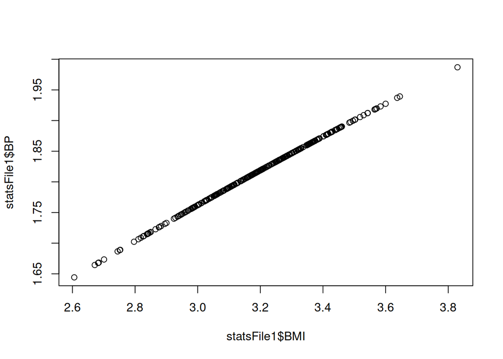

```r
#plot
plot(statsFile1$BMI, statsFile1$BP)
```

**Reason for choosing model** I chose the simple linear regression to check the dependencies between the two variables, BMI and BP because: i)I assume that the two independent variables are normally distributed ii)I also assumed that the variance of the distribution of the dependent variable should be constant for all values of the independent variable

**Results interpretation** After plotting the simple linear regression model for BMI and BP, it shows that when BMI increases, BP also increases, therefore, BP depends on BMI (change in BMI causes change in BP) The Multiple R-squared of 0.9995 tells me that 99.95% variability in BP is caused by BMI.

#### 4)How does BMI compare in the different sampling locations?

```r
#BMI mean and median to determine whether BMI data is normally distributed or not
mean(statsFile1, )
```

```
## [1] NA
```

```r
statsFile1 %>% group_by(Location) %>% summarise(mean = mean(BMI), median(BMI))
```

```
## # A tibble: 3 × 3
##   Location  mean `median(BMI)`
##   <chr>    <dbl>         <dbl>
## 1 A         3.18          3.21
## 2 B         3.21          3.19
## 3 C         3.17          3.17
```

```r
#BMI variance to determine whether BMI data is normally distributed or not
statsFile1 %>% group_by(Location) %>% summarize(variance = var(BMI))
```

```
## # A tibble: 3 × 2
##   Location variance
##   <chr>       <dbl>
## 1 A          0.0369
## 2 B          0.0395
## 3 C          0.0367
```

```r
anova_result <- aov(BMI~Location, statsFile1)
summary(anova_result)
```

```
##              Df Sum Sq Mean Sq F value Pr(>F)
## Location      2  0.097 0.04834   1.278   0.28
## Residuals   317 11.991 0.03782
```

**Reason for choosing model** I chose Anova (analysis of variance) as a test because: i) Anova is used to compare qualitative and quantitative variables ii) There are more than two variables that are parametric in nature as determined above iii) The populations have equal population variance as determined above

**Results interpretation** The p-value is greater than the significance level (0.05) thus suggesting that there is not enough evidence to reject the null hypothesis that the means of the groups are equal.

This suggests that there may not be a statistically significant difference in means among the different levels of the Location variable.

#### 5) How does disease status depend on both BMI and BP?

```r
# binary logistic regression
disease_status_dependancy <- glm(Status~BMI + BP, data = statsFile1, family = "binomial")

summary(disease_status_dependancy)
```

```
##
## Call:
## glm(formula = Status ~ BMI + BP, family = "binomial", data = statsFile1)
##
## Deviance Residuals:
##    Min      1Q  Median      3Q     Max
## -1.189  -1.155  -1.088   1.198   1.339
##
## Coefficients:
##             Estimate Std. Error z value Pr(>|z|)
## (Intercept)   -11.64      84.53  -0.138    0.890
## BMI            -4.15      25.88  -0.160    0.873
## BP             13.67      92.02   0.149    0.882
##
## (Dispersion parameter for binomial family taken to be 1)
##
##     Null deviance: 443.30  on 319  degrees of freedom
## Residual deviance: 442.99  on 317  degrees of freedom
## AIC: 448.99
##
## Number of Fisher Scoring iterations: 3
```

**Reason for choosing model** I chose to use binary logistic regression to determine how BMI and BP determine disease status because there are 3 variables in play, with disease status being a qualitative dependent variable having 2 groups namely; disease and no-disease. Disease status is dependent on BMI and BP.

**Results interpretation** #Coefficients The intercept (-11.64)) is the log-odds of the outcome when both BMI and BP are zero. In this case, the intercept is not statistically significant (p-value = 0.890), meaning it is not significantly different from zero.

The coefficient for BMI (-4.15) represents the change in the log-odds of the outcome for a one-unit increase in BMI, holding BP constant. However, the p-value (0.873) suggests that the effect of BMI is not statistically significant.

The coefficient for BP (13.67) represents the change in the log-odds of the outcome for a one-unit increase in BP, holding BMI constant. Similar to BMI, the p-value (0.882) indicates that the effect of BP is not statistically significant.

Therefore the model does not provide strong evidence of a relationship between the predictors and the binary outcome.